# Predicting and Analyzing U.S. Flight Delays: Identifying Key Factors and Improving Forecast Accuracy

2024-10-28

#SMART question - **What time of day do flights experience the highest frequency of delays? Are there specific hours when certain types of delays, such as (NAS, Security, or Late Aircraft) are more frequent?**

```r
library(tidyverse)
library(lubridate)
library(scales)
library(gridExtra)
library(ggplot2)
library(stats)
library(reshape2)
```

```r
# Read the dataset
flights <- read.csv("/Users/rasika/Desktop/DATS 6101/Midterm/Flight_delay.csv")
```

# Data Preprocessing and Summary Statistics

```r
# Convert time fields to proper format
flights$DepTime <- as.numeric(flights$DepTime)
flights$hour <- floor(flights$DepTime/100)

# Create binary delay indicator
flights$is_delayed <- ifelse(flights$DepDelay > 15, 1, 0)

# Basic summary statistics
summary(flights)
```

```
##    DayOfWeek        Date              DepTime        ArrTime       CRSArrTime
##  Min.   :1.00   Length:484551      Min.   :   1   Min.   :   1   Min.   :   1
##  1st Qu.:2.00   Class :character   1st Qu.:1234   1st Qu.:1327   1st Qu.:1339
##  Median :4.00   Mode  :character   Median :1620   Median :1737   Median :1723
##  Mean   :3.99                      Mean   :1564   Mean   :1618   Mean   :1652
##  3rd Qu.:6.00                      3rd Qu.:1928   3rd Qu.:2049   3rd Qu.:2025
##  Max.   :7.00                      Max.   :2400   Max.   :2400   Max.   :2359
##  UniqueCarrier        Airline            FlightNum      TailNum
##  Length:484551      Length:484551      Min.   :   1   Length:484551
##  Class :character   Class :character   1st Qu.: 629   Class :character
##  Mode  :character   Mode  :character   Median :1514   Mode  :character
##                                        Mean   :2139
##                                        3rd Qu.:3683
##                                        Max.   :8403
##  ActualElapsedTime CRSElapsedTime    AirTime       ArrDelay       DepDelay
##  Min.   : 15       Min.   :-21    Min.   :  0   Min.   :  15   Min.   :   6
##  1st Qu.: 80       1st Qu.: 79    1st Qu.: 57   1st Qu.:  25   1st Qu.:  23
##  Median :116       Median :114    Median : 90   Median :  42   Median :  40
##  Mean   :135       Mean   :131    Mean   :109   Mean   :  61   Mean   :  57
##  3rd Qu.:168       3rd Qu.:162    3rd Qu.:139   3rd Qu.:  76   3rd Qu.:  72
##  Max.   :727       Max.   :602    Max.   :609   Max.   :1707   Max.   :1710
##     Origin          Org_Airport            Dest           Dest_Airport
##  Length:484551      Length:484551      Length:484551      Length:484551
##  Class :character   Class :character   Class :character   Class :character
##  Mode  :character   Mode  :character   Mode  :character   Mode  :character
##
##
##
##     Distance        TaxiIn         TaxiOut      Cancelled CancellationCode
##  Min.   :  31   Min.   :  0.0   Min.   :  0   Min.   :0   Length:484551
##  1st Qu.: 331   1st Qu.:  4.0   1st Qu.: 11   1st Qu.:0   Class :character
##  Median : 599   Median :  5.0   Median : 15   Median :0   Mode  :character
##  Mean   : 752   Mean   :  6.8   Mean   : 19   Mean   :0
##  3rd Qu.: 992   3rd Qu.:  8.0   3rd Qu.: 22   3rd Qu.:0
##  Max.   :4502   Max.   :207.0   Max.   :383   Max.   :0
##     Diverted  CarrierDelay   WeatherDelay     NASDelay    SecurityDelay
##  Min.   :0   Min.   :   0   Min.   :   0   Min.   :   0   Min.   :  0
##  1st Qu.:0   1st Qu.:   0   1st Qu.:   0   1st Qu.:   0   1st Qu.:  0
##  Median :0   Median :   2   Median :   0   Median :   1   Median :  0
##  Mean   :0   Mean   :  17   Mean   :   3   Mean   :  14   Mean   :  0
##  3rd Qu.:0   3rd Qu.:  19   3rd Qu.:   0   3rd Qu.:  13   3rd Qu.:  0
##  Max.   :0   Max.   :1707   Max.   :1148   Max.   :1357   Max.   :392
##  LateAircraftDelay      hour        is_delayed
##  Min.   :   0      Min.   : 0.0   Min.   :0.000
##  1st Qu.:   0      1st Qu.:12.0   1st Qu.:1.000
##  Median :  13      Median :16.0   Median :1.000
##  Mean   :  27      Mean   :15.3   Mean   :0.879
##  3rd Qu.:  36      3rd Qu.:19.0   3rd Qu.:1.000
##  Max.   :1254      Max.   :24.0   Max.   :1.000
```

```r
# Check for missing values
colSums(is.na(flights))
```

```
##         DayOfWeek              Date           DepTime           ArrTime
##                 0                 0                 0                 0
##        CRSArrTime     UniqueCarrier           Airline         FlightNum
##                 0                 0                 0                 0
##           TailNum ActualElapsedTime    CRSElapsedTime           AirTime
##                 0                 0                 0                 0
##          ArrDelay          DepDelay            Origin       Org_Airport
##                 0                 0                 0                 0
##              Dest      Dest_Airport          Distance            TaxiIn
##                 0                 0                 0                 0
##           TaxiOut         Cancelled  CancellationCode          Diverted
##                 0                 0                 0                 0
##      CarrierDelay      WeatherDelay          NASDelay     SecurityDelay
##                 0                 0                 0                 0
## LateAircraftDelay              hour        is_delayed
##                 0                 0                 0
```

# Descriptive Statistics

Distribution of delays by hours

```r
hourly_stats <- flights %>%
  group_by(hour) %>%
  summarise(
    total_flights = n(),
    delayed_flights = sum(is_delayed, na.rm = TRUE),
    delay_rate = delayed_flights/total_flights,
    avg_delay = mean(DepDelay, na.rm = TRUE),
    sd_delay = sd(DepDelay, na.rm = TRUE),
    carrier_delay = mean(CarrierDelay, na.rm = TRUE),
    weather_delay = mean(WeatherDelay, na.rm = TRUE),
    nas_delay = mean(NASDelay, na.rm = TRUE),
    security_delay = mean(SecurityDelay, na.rm = TRUE),
    late_aircraft_delay = mean(LateAircraftDelay, na.rm = TRUE)
  )

print(hourly_stats)
```

```
## # A tibble: 25 × 11
##     hour total_flights delayed_flights delay_rate avg_delay sd_delay
##    <dbl>         <int>           <dbl>      <dbl>     <dbl>    <dbl>
##  1     0          3709            3540      0.954     128.      93.5
##  2     1          1373            1349      0.983     160.     105.
##  3     2           372             367      0.987     183.     111.
##  4     3           103             102      0.990     217.     124.
##  5     4            54              53      0.981     192.     219.
##  6     5           192              97      0.505      46.6    124.
##  7     6          4954            2953      0.596      25.4     56.3
##  8     7          9994            7196      0.720      34.3     54.5
##  9     8         15267           11612      0.761      38.5     47.6
## 10     9         17880           14490      0.810      44.2     46.1
## # ℹ 15 more rows
## # ℹ 5 more variables: carrier_delay <dbl>, weather_delay <dbl>,
## #   nas_delay <dbl>, security_delay <dbl>, late_aircraft_delay <dbl>
```

# Overall Delay pattern by hour

This bar chart showcases Peak Delay Times, lowest delay period and gradual increase in delay fo throughout the day.

Conclusion - Highest delay rates observed during late night and early morning hours (00:00–3:00) and late evening hours (18:00–23:00). Delay rate significantly drops around 5:00 AM, indicating fewer delays early in the morning. Steady increase in delay rate starting from morning hours (6:00) until afternoon, with a noticeable peak by late evening.

[figure not shown]

```r
ggplot(hourly_stats, aes(x = factor(hour), y = delay_rate, fill = delay_rate)) +
  geom_bar(stat = "identity") +
  scale_fill_gradient(low = "lightgreen", high = "red") +
  theme_minimal() +
  labs(title = "Hourly Flight Delay Distribution",
       x = "Hour of Day",
       y = "Delay Rate (%)",
       caption = "Delays > 15 minutes considered",
       fill = "Delay %") +
  theme(
    plot.title = element_text(hjust = 0.5, size = 14),
    axis.text.x = element_text(angle = 0),
    legend.position = "right"
  ) +
  scale_y_continuous(labels = scales::percent_format(scale = 1))
```

# Types of Delays by hour

This time series line graph shows the delay type and which type is causing significant, moderate and limited impact.

Conclusion -> Most Dominant Delay type was Late Aircraft arrival on runway, Second Most common was Carrier Delays, Minimal Delay type was Security, Moderate Delay types were Weather and NAS.

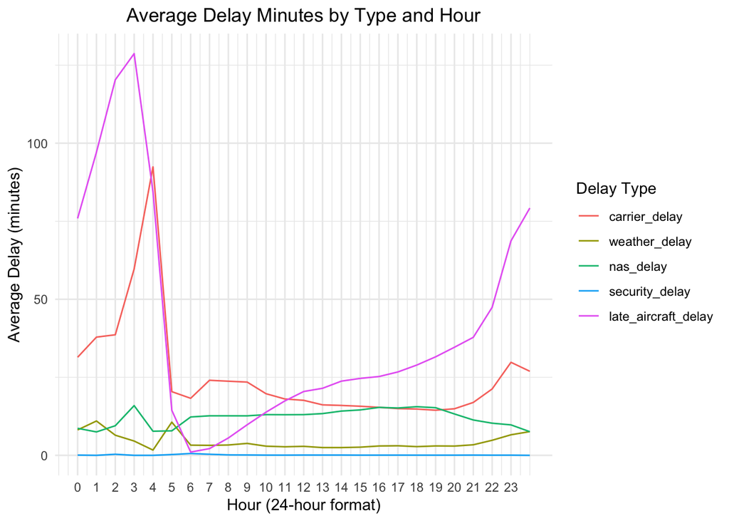

```r
delay_types <- hourly_stats %>%
  select(hour, carrier_delay, weather_delay, nas_delay,
         security_delay, late_aircraft_delay) %>%
  melt(id.vars = "hour")

ggplot(delay_types, aes(x = hour, y = value, color = variable)) +
  geom_line() +
  theme_minimal() +
  labs(title = "Average Delay Minutes by Type and Hour",
       x = "Hour (24-hour format)",
       y = "Average Delay (minutes)",
       color = "Delay Type") +
  scale_x_continuous(breaks = 0:23) +
  theme(plot.title = element_text(hjust = 0.5))
```

# Top 5 Airports Delay Analysis

This code performs an analysis of delay rates across the top 5 busiest U.S. airports, specifically examining how delays vary by the hour of the day. It first identifies the top 5 airports by total flight count. For each of these airports, the code calculates the average delay rate and average delay time by hour. Finally, it generates a line plot showing the hourly delay rates for each of these airports, allowing for visual comparison of delay trends throughout the day. This analysis provides insight into peak delay hours and helps identify patterns specific to high-traffic airports.

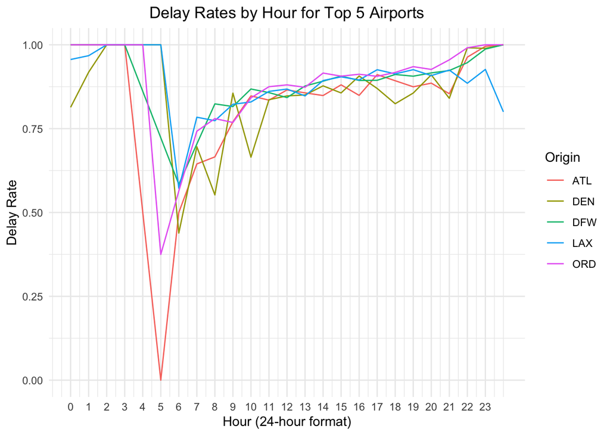

```r
top_airports <- flights %>%
  group_by(Origin) %>%
  summarise(total_flights = n()) %>%
  arrange(desc(total_flights)) %>%
  head(5)

airport_hourly <- flights %>%
  filter(Origin %in% top_airports$Origin) %>%
  group_by(Origin, hour) %>%
  summarise(
    delay_rate = mean(is_delayed, na.rm = TRUE),
    avg_delay = mean(DepDelay, na.rm = TRUE)
  )

ggplot(airport_hourly, aes(x = hour, y = delay_rate, color = Origin)) +
  geom_line() +
  theme_minimal() +
  labs(title = "Delay Rates by Hour for Top 5 Airports",
       x = "Hour (24-hour format)",
       y = "Delay Rate") +
  scale_x_continuous(breaks = 0:23) +
  theme(plot.title = element_text(hjust = 0.5))
```

# Result Summary